# Quality of Motion Analysis

Merrill Asp

June 4, 2017

## Overview

We create a machine learning predictor for the Human Activity Recognition data from Groupware@LES http://groupware.les.inf.puc-rio.br/har. We first perform some exploratory analysis, which leads us to build our predictor using a random forest method from data preprocessed with primary component analysis. We show that the resulting predictor is 81% to 82% accurate using 10-fold cross-validation, and finally we produce predictions for 20 observations in a testing dataset.

## Loading and Preprocessing Data

First we must load the prepared testing and training data

```r
library(caret)
if(!file.exists("pml-training.csv")) {
  download.file("https://d396qusza40orc.cloudfront.net/predmachlearn/pml-training.csv", "pml-training.csv")
}
if(!file.exists("pml-testing.csv")) {
  download.file("https://d396qusza40orc.cloudfront.net/predmachlearn/pml-testing.csv", "pml-testing.csv")
}
training.data.in <- read.csv("pml-training.csv")
testing.data.in <- read.csv("pml-testing.csv")
```

For some simple preprocessing, we notice that the first column of the data is simply the row number, so we can remove it.

```r
all(training.data.in[,1] == 1:nrow(training.data.in))
```

```
## [1] TRUE
```

```r
training.data.in <- training.data.in[,2:160]
testing.data.in <- testing.data.in[,2:160]
```

Also, the testing dataset has several variables that all have missing values, and so cannot be used for prediction. We can remove these variables as well.

```r
valid.predictors <- sapply(1:ncol(testing.data.in), function(i) !all(is.na(testing.data.in[,i])))
training.data.in <- training.data.in[,valid.predictors]
testing.data.in <- testing.data.in[,valid.predictors]
```

We also have a `user_name` variable, but we cannot rely on having the same users in our testing set, so we should remove this variable (this also prevents overfitting to particular users). Three other variables (`cvtd_timestamp`, `new_window` and `num_window`) have little variation, so we choose to ignore them.

```r
predictors.to.remove <- c(1,4,5,6)
training.data.in <- training.data.in[,-predictors.to.remove]
testing.data.in <- testing.data.in[,-predictors.to.remove]
dim(training.data.in)
```

```
## [1] 19622    55
```

```r
dim(testing.data.in)
```

```
## [1] 20 55
```

We thus have 19622 observations of 55 variables to train with in order to verify against our 20 observations of those variables in the test data.

## Exploratory Analysis

The quality of motion, what we are trying to predict, is in the `classe` variable. There are many other variables relating to detailed aspects of subject motion. This is only a sample

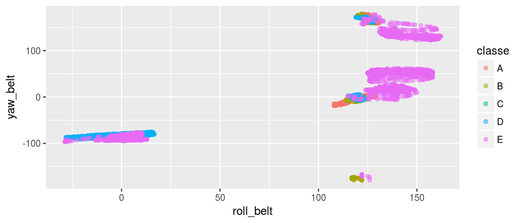

```r
library(ggplot2)
ggplot(training.data.in, aes(x=roll_belt, y=yaw_belt, color=classe)) +
  geom_point(alpha=0.5)
```

There seems to be no obvious way to distinguish the `classe` groups, at least from this first glance. A matrix of pair plots was also created for groups of ten variables at a time, which are too large and not informative enough to reproduce here.

## Machine Learning Procedure

There are a large number of variables, so we will check to see if any of the variables are highly correlated

```r
corr.matrix <- abs(cor(training.data.in[,-55])) # this removes the non-numeric classe column
diag(corr.matrix) <- 0 # we ignore the correlation of variables with themselves
which(corr.matrix > 0.9, arr.ind = TRUE)
```

```
##                  row col
## total_accel_belt   6   3
## accel_belt_y      11   3
## accel_belt_z      12   3
## accel_belt_x      10   4
## roll_belt          3   6
## accel_belt_y      11   6
## accel_belt_z      12   6
## pitch_belt         4  10
## roll_belt          3  11
## total_accel_belt   6  11
## accel_belt_z      12  11
## roll_belt          3  12
## total_accel_belt   6  12
## accel_belt_y      11  12
## gyros_arm_y       21  20
## gyros_arm_x       20  21
## gyros_dumbbell_z  35  33
## gyros_forearm_z   48  33
## gyros_dumbbell_x  33  35
## gyros_forearm_z   48  35
## gyros_dumbbell_x  33  48
## gyros_dumbbell_z  35  48
```

Since many of our variables are highly correlated, doing primary component preprocessing should decrease variability and retain the most important information about our predictors. This will also help in the issue of having a large number of variables without obvious predicting power.

```r
library(caret)
preProc <- preProcess(training.data.in[,-55], method="pca", thresh=0.8) # find enough new predictors to explain 80% of the data variation
trainPC <- predict(preProc, training.data.in[,-55]) # calculate the values of our simplified predictors
pc.training <- cbind(trainPC, classe=training.data.in$classe) # bind the classe variable back on
```

The choice to create enough new predictors to account for 80% of the variation in the data was motivated by time needed to fit more complicated models, which we will see below.

Because the quality of motion is likely a function of interactions between our variables, we can then try a non-linear method like a decision tree to create our predictor. However, this turns out not to be robust enough (several trials yielded trees that entirely lacked a `classe="B"` or `classe="C"` leaf).

We thus try the more robust random forest technique, limiting the amount of data in our training set to constrain the amount of time to build the predictor. This produces more validation sets than expected, but this is not a problem.

```r
set.seed(857)
partition <- createFolds(pc.training$classe, k=10, list=FALSE)
partition.indices1 <- which(partition == 1)
pc.training.slice <- pc.training[partition.indices1,]
decisionTree <- train(classe ~ ., method="rf", data=pc.training.slice)
confusionMatrix(pc.training.slice$classe, predict(decisionTree))$table
```

```
##           Reference
## Prediction   A   B   C   D   E
##          A 558   0   0   0   0
##          B   0 380   0   0   0
##          C   0   0 342   0   0
##          D   0   0   0 321   0
##          E   0   0   0   0 360
```

We can now perform some cross validation on the other partitions of our data

```r
validation.indices <- lapply(2:10, function(i) which(partition == i)) # get indices for validation sets
validation.stats <- function (i) {
  validation <- pc.training[validation.indices[[i]],]
  confusionMatrix(validation$classe, predict(decisionTree, newdata=validation))
}
accuracy.stats <- sapply(1:9, function(i) validation.stats(i)$overall["Accuracy"])
m.a <- mean(accuracy.stats) # mean accuracy
sd.a <- sd(accuracy.stats) # standard deviation of accuracy
m.a + c(-1,1)*qt(.975, 8)*sd.a/sqrt(9) # 95% confidence interval for accuracy
```

```
## [1] 0.8128761 0.8219117
```

Our random forest predictor is thus about 81% to 82% accurate within a 95% confidence interval. In other words, we can expect about 18% to 19% out-of-sample error.

Finally, we can apply our predictor to the test data and see what predictions we obtain.

```r
testPC <- predict(preProc, testing.data.in[,-55]) # calculate the values of our simplified predictors in the test data
predict(decisionTree, newdata=testPC)
```

```
##  [1] A A A A A E D B A A B C B A E A A E D B
## Levels: A B C D E
```